# Regresija

## Uvod

Pri regresiji sva se odločila, da bova uporabljala naslednje algoritme: - Principal least squares - `plsr` - Support vector machines - `svm` - Random forest - `randomForest` - Nevronska mreža z enim skritim nivojom - `nnet`

Uporabila sva naslednje knjižnice:

```r
library(pls)
library(e1071)
library(randomForest)
library(nnet)
```

Modele sva na podatkih gradila vzporedno. To pomeni, da sva jih istočasno preizkušala na napovedih ozona in majhnih delcev. Za mero točnosti sva vzela korelacijski koeficient med napovedanimi in resničnimi podatki in pa koren povprečnega kvadrata napake (RMSE). Na začetku sva uporabljala učno in testno množico, kasneje pa sva dodala še cross-validation.

Manjkajoče podatke v neodvisnih atributih sva nadomestila povprečnimi vrednostmi atributov. Preizkusila sva tudi napovedovanje s funkcijo `randomForest`, a je to dajalo skoraj enake, včasih celo slabše rezultate.

Za izbiro atributov sva preizkusila izbiranje glede na vrednost RReliefFa s preprosto funkcijo za filtriranje:

```r
rrelieffFilter <- function(formula, dfs, thresh=0, est="RReliefFequalK")
{
  evald <- attrEval(formula, data=dfs$all, estimator=est)
  filt  <- c(evald >= thresh, TRUE)

  out.name <- as.character(formula[2])
  lapply(dfs, function(df) df[, filt])
}
```

Tako filtriranje rahlo izboljša napovedi pri algoritmu `svm`, pri ostalih pa jih poslabša.

Za risanje grafov in izračun korelacijskega koeficienta sva uporabila naslednjo funkcijo:

```r
getCor <- function(model, dfs, response, plot=T, ...)
{
  predicted <- predict(model, newdata=dfs$test, ...)
  actual    <- dfs$test[, response]
  if (plot) {
    maxval <- max(predicted, actual)
    minval <- min(predicted, actual)

    plot(c(minval, maxval), c(minval, maxval), col="red", type="l"
        , xlab="actual", ylab="predicted")
    points(actual, predicted, pch=20, col="blue"
          , xlim=c(minval, maxval), ylim=c(minval,maxval))
  }
  cor(actual, predicted)
}
```

## Priprava podatkov

Podatke sva pripravila s funkcijo:

```r
prepData <- function( all.df, output.col, exclude.col
                    , test.percent=0.1, impute=imputeMean, log.out=F, log.rw=F)
{

  # rm na in output
  df <- all.df[!is.na(all.df[, output.col]), ]
  # rm exclude.col
  df <- df[, !names(df) %in% c(exclude.col, "DAY")]
  # binarize TRAJ
  df <- binarizeTraj(df)
  # winsorize RAIN
  max.rain <- 100
  df$RAIN[df$RAIN > max.rain] <- max.rain

  # impute missing values in inputs
  cnames    <- colnames(df)
  resp.i    <- which(cnames == output.col)
  imputed.x <- impute(df[, -resp.i])
  df        <- named(cbind(imputed.x, df[, resp.i]), col=cnames)

  if (log.out)
    df[, output.col] <- log(1 + df[, output.col])

  if (log.rw) {
    df$WIND <- log(1 + df$WIND)
    df$RAIN <- log(1 + df$RAIN)
  }

  # split data into test and learn data
  n    <- nrow(df)
  test <- sample(1:n, round(n * test.percent))

  list( learn = df[-test, ]
      , test  = df[ test, ]
      , all   = df )

}
```

Funkcija binarizira `TSHORT` in `TLONG`, omeji `RAIN`, nadomesti manjkajoče vrednosti, po potrebi logartmira atribute in podatke razdeli na učno in testno množico.

Pred uporabo algoritma `nnet` sva podatke tudi skalirala.

## Napovedovanje ozona

Napvedovanje ozona je bilo zelo uspešno. Najboljše rezultate je dal algoritem `randomForest`

```r
library(ipred)

O3.data <- prepData(all.data, "O3", exclude.col=c("PLARGE", "PSMALL", "DATE"))
```

### PLS:

```r
pls.model <- plsr(O3 ~ ., data=O3.data$learn)
pls.rmse  <- errorest( O3 ~ .
                     , O3.data$all
                     , model=plsr
                     , predict=function(...)
                                 predict(..., ncomp=3))
pls.cor   <- getCor(pls.model, O3.data, "O3", ncomp=3)
```

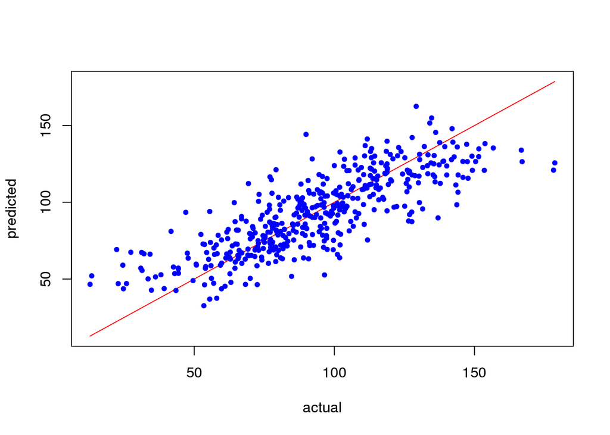

```r
list(rmse=pls.rmse$error, cor=pls.cor)
```

```
## $rmse
## [1] 16.93386
##
## $cor
## [1] 0.8102331
```

### SVM:

```r
O3.data.svm <- rrelieffFilter(O3 ~ ., O3.data, thresh=0)

svm.model <- best.svm(O3 ~ ., data=O3.data.svm$learn)
svm.rmse  <- errorest( O3 ~ .
                     , O3.data.svm$all
                     , model=best.svm)
svm.cor   <- getCor(svm.model, O3.data.svm, "O3")
```

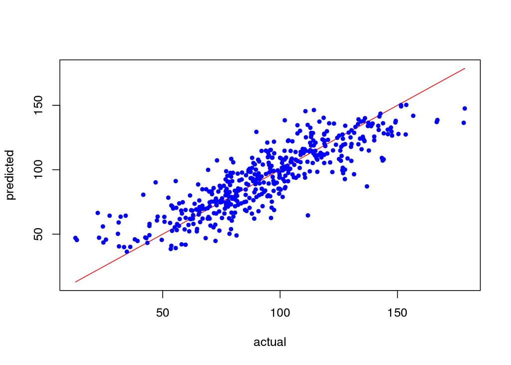

```r
list(rmse=svm.rmse$error, cor=svm.cor)
```

```
## $rmse
## [1] 14.24674
##
## $cor
## [1] 0.864754
```

### Random Forest:

```r
rf.model <- randomForest(O3 ~ ., data=O3.data$learn)
rf.rmse  <- errorest( O3 ~ .
                    , O3.data$all
                    , model=randomForest)
rf.cor   <- getCor(rf.model, O3.data, "O3")
```

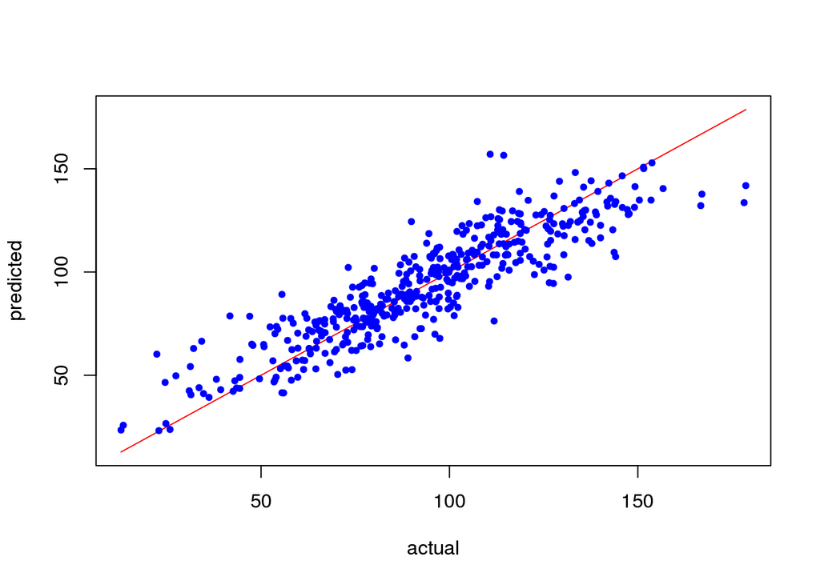

```r
list(rmse=rf.rmse$error, cor=rf.cor)
```

```
## $rmse
## [1] 12.81268
##
## $cor
## [1] 0.8958747
```

### NNET:

```r
# %.% je operator za kompozitum dveh funkcij
O3.data.sc <- lapply(O3.data, as.data.frame %.% scale)

ann.model <- nnet( O3 ~ ., data=O3.data.sc$learn
                 , maxit=3000, size=15, trace=F, linout=T)
ann.rmse  <- errorest( O3 ~ .
                     , O3.data.sc$all
                     , model=function(...)
                               nnet(..., maxit=3000
                                       , size=15, trace=F, linout=T))
ann.cor   <- getCor(ann.model, O3.data.sc, "O3")
```

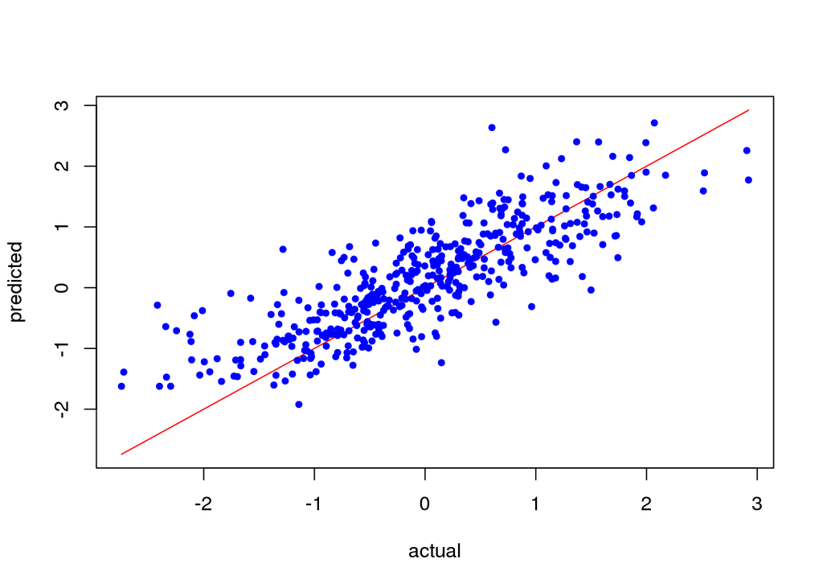

```r
list(rmse=ann.rmse$error, cor=ann.cor)
```

```
## $rmse
## [1] 0.5146514
##
## $cor
##           [,1]
## [1,] 0.8322293
```

### Primerjava algoritmov

```r
list(pls = pls.rmse, svm = svm.rmse, rf = rf.rmse, ann = ann.rmse)
```

```
## $pls
##
## Call:
## errorest.data.frame(formula = O3 ~ ., data = O3.data$all, model = plsr,
##     predict = function(...) predict(..., ncomp = 3))
##
##   10-fold cross-validation estimator of root mean squared error
##
## Root mean squared error:  16.9339
##
##
## $svm
##
## Call:
## errorest.data.frame(formula = O3 ~ ., data = O3.data.svm$all,
##     model = best.svm)
##
##   10-fold cross-validation estimator of root mean squared error
##
## Root mean squared error:  14.2467
##
##
## $rf
##
## Call:
## errorest.data.frame(formula = O3 ~ ., data = O3.data$all, model = randomForest)
##
##   10-fold cross-validation estimator of root mean squared error
##
## Root mean squared error:  12.8127
##
##
## $ann
##
## Call:
## errorest.data.frame(formula = O3 ~ ., data = O3.data.sc$all,
##     model = function(...) nnet(..., maxit = 3000, size = 15,
##         trace = F, linout = T))
##
##   10-fold cross-validation estimator of root mean squared error
##
## Root mean squared error:  0.5147
```

```r
list(pls = pls.cor, svm = svm.cor, rf = rf.cor, ann = ann.cor)
```

```
## $pls
## [1] 0.8102331
##
## $svm
## [1] 0.864754
##
## $rf
## [1] 0.8958747
##
## $ann
##           [,1]
## [1,] 0.8322293
```